# Orange Roughy Eastern Zone: Biological Summary from the Acoustic Survey 2024

sutton

2025-01-28

# Set up

libraries required

load data

```r
### Biological Index
Roughy <- read_csv("Results/OREastern_Tidy_87to2019.csv", col_types = list(ShotWeight_kg = col_double(), mark = col_character()))
### AGE
Age <- read_csv("Results/RoughyEZ_AgeIndex_1986to2019.csv")
```

```
## ──────────────────────────────────────────────────────── Delimiter: "," chr
## (5): Zone, Ground, month, Sex, Mark dbl (6): ...1, Year, Length_cm, Age, O,
## Sex_no
```

```r
Age2024_Owgt <- read_csv("Data/Roughy_Age2024_owgt.csv")
Age_2019 <- read_csv("Data/RoughyAge2019.csv")
```

```
## ──────────────────────────────────────────────────────── Delimiter: "," chr
## (13): Month, AreaCapture, Alpha_zone, Zone, Gear, Sex, lencode, Reader, ... dbl
## (11): CSIROCode, Year, Day, Batch, Specimen_ID:, Floorlength, Age1...14,... lgl
## (1): Edge_Type
```

```r
### 2024 data
Bio2024 <- read_csv("Data/RoughyBiologicals_EZ_2024.csv")
```

```
## ──────────────────────────────────────────────────────── Delimiter: "," chr
## (15): Vessel, Voyage, Date, Species_Code, Catch_Location, * Tag / Band ... dbl
## (4): Shot, Life_status, Length_cm, Gonad_Stage lgl (3): Weight Whole (kgs),
## Weight Dressed (kg), ...22 time (1): Time
```

```r
Shot2024 <- read_csv("Data/RoughyShot_EZ_2024.csv")
```

```
## ──────────────────────────────────────────────────────── Delimiter: "," chr
## (4): Location, Date, Month, Day dbl (9): Shot, Year, Net_depth_first_contact,
## Net_depth_when_hauling, Tow_d... lgl (1): ...14 time (1): time
```

```r
discard2024 <- read_csv("Data/Roughy2024_discards.csv")
cc <- read_csv("Data/Roughy2024_catchcomp.csv")
```

| ## Biolgical Index Data - add the new data |
| --- |

manipulate 2024 data

```r
Shot2024_ed <- Shot2024 %>%
  select(Shot,Location,Day, Month, Year, Date,Lengths,Otoliths,Total_catch_weight_kg)

Bio2024_1 <- Bio2024 %>%
  left_join(Shot2024_ed, by = "Shot")
```

explore fields

```r
colnames(Roughy)
```

```
##  [1] "...1"          "zone"          "year"          "Area_MS"
##  [5] "Survey"        "Shot"          "sex"           "stage"
##  [9] "weight_kg"     "SLadj_cm"      "Otoliths"      "mark"
## [13] "vessel"        "Date"          "Shot type"     "lat1"
## [17] "long1"         "ShotWeight_kg"
```

```r
colnames(Bio2024_1)
```

```
##  [1] "Vessel"                "Voyage"                "Shot"
##  [4] "Date.x"                "Time"                  "Species_Code"
##  [7] "Catch_Location"        "* Tag / Band or Scar"  "Tag or Band Number"
## [10] "Life_status"           "Fate"                  "Length_method"
## [13] "Length_cm"             "length_Code"           "Weight Whole (kgs)"
## [16] "Weight Dressed (kg)"   "Process Code"          "Sex"
## [19] "Sample_ss:nn"          "Sample_Code"           "Gonad_Stage"
## [22] "...22"                 "Comments"              "Location"
## [25] "Day"                   "Month"                 "Year"
## [28] "Date.y"                "Lengths"               "Otoliths"
## [31] "Total_catch_weight_kg"
```

add relevant columns to the new data

```r
Bio <- Bio2024_1 %>%
  mutate(zone = "Eastern", year = 2024, Area_MS = Location, Survey = Voyage, stage = Gonad_Stage,
         SLadj_cm = Length_cm)

 Bio_1 <- Bio %>%
   select(zone, year, Area_MS, Survey, Shot, sex = Sex, stage, SLadj_cm, Otoliths, vessel = Vessel, Date= Date.x, ShotWeight_kg = Total_catch_weight_kg)
```

append 2024 data to the biological index data

```r
Roughy <- Roughy %>%
  bind_rows(Bio_1)
```

```r
write_csv(Roughy,"Results/Roughy_EZIndex_1987to2024.csv")
```

explore data

```r
Roughy %>%
  filter(year==2024) %>%
  #group_by(sex) %>%
  distinct(stage,sex)
```

```
## # A tibble: 11 × 2
##    stage sex
##    <dbl> <chr>
##  1     5 F
##  2     5 M
##  3     6 M
##  4     6 F
##  5     4 <NA>
##  6     4 M
##  7     2 M
##  8     3 M
##  9     4 F
## 10     3 F
## 11    NA <NA>
```

# Tables and Figures

| ## Summarise bio data 2024 |
| --- |

```r
BioSummary24 <- Bio2024_1 %>%
  dplyr::group_by(Shot,Sex) %>%
  dplyr::summarise(n= n())
BioSummary24 <- spread(BioSummary24, key = Sex,value = n)
```

add other required fields

```r
BioSummary24 <- BioSummary24 %>%
  left_join(Shot2024_ed, by= "Shot") %>%
  select(Ground = Location, Shot, Date, Total_catch_weight_kg, F, M, Total_Fish_Measured = Lengths, Otoliths_taken = Otoliths)
```

add discards

select relevant fields

```r
discard2024 <- discard2024 %>%
  select(Shot,retained,discarded)
```

join to summary

```r
BioSummary24 <- BioSummary24 %>%
  left_join(discard2024, by = "Shot")
```

Write data

```r
#write.csv(BioSummary24,"C:/Users/sut109/OneDrive - CSIRO/roughy - working/Figures/t2.4_sumshot_24.csv")
```

```r
BioSummary24_ground <- BioSummary24 %>%
  select(Ground,Shot,retained,discarded) %>%
  dplyr::group_by(Ground,Shot) %>%
  dplyr::summarise(R = sum(retained), D = sum(discarded)) %>%
  mutate(TW = R+D) %>%
  mutate(discardpct = (D/TW)*100)
BioSummary24_ground %>%
  summarise(mean(discardpct))
```

```
##   mean(discardpct)
## 1         1.093226
```

Detailed discard catch complication

```r
Discard_cc <-cc %>%
  filter(Fate == "D") %>%
  dplyr::group_by(Species,Shot) %>%
  dplyr::summarise(TW =sum(`Total Weight (kg)`))
Discard_cc_1 <- Discard_cc %>%
  left_join(Shot2024, by = "Shot") %>%
  select(Species,Shot, Ground = Location, TW) %>%
  drop_na(Ground)

discard_Species <- Discard_cc_1 %>%
  dplyr::group_by(Species) %>%
  dplyr::summarise(sum(TW))
```

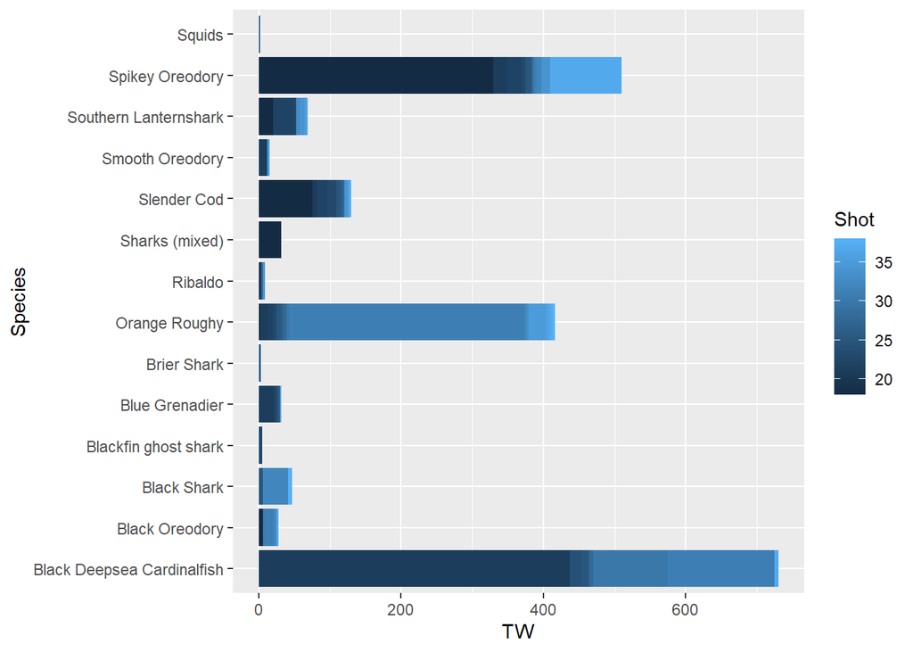

```r
ggplot(Discard_cc_1, aes(x = TW, y = Species, fill = Shot))+
  geom_bar(stat = "identity")
```

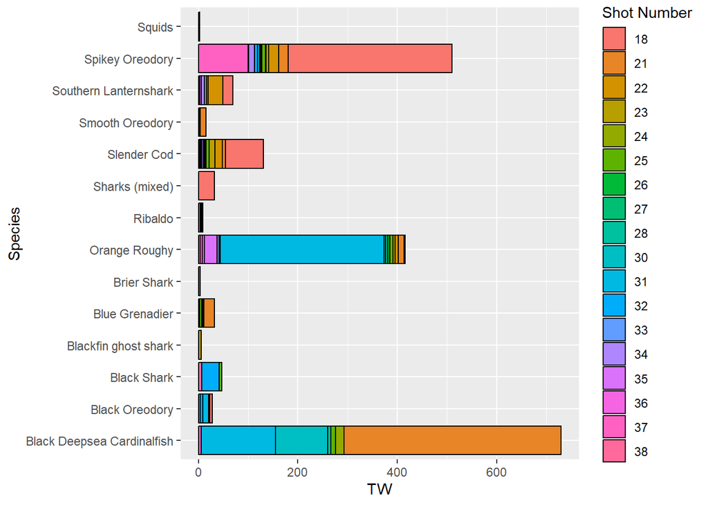

```r
ggplot(Discard_cc_1, aes(x = TW, y = Species, fill = as.factor(Shot))) +
  geom_bar(stat = "identity", color = "black", position = "stack")+
  labs(fill = "Shot Number")  # Customize legend title
```

```r
  #facet_wrap(~Ground)
```

| ### summary table with additional 2024 data |
| --- |
| ### Length - index |

Average Standard Length (cm) of orange roughy Eastern Zone spawning population, showing males and females at St Helens and St Patricks for 1987 to 2024. Error bars are 95% confidence limits (updated from Kloser et al. 2016)

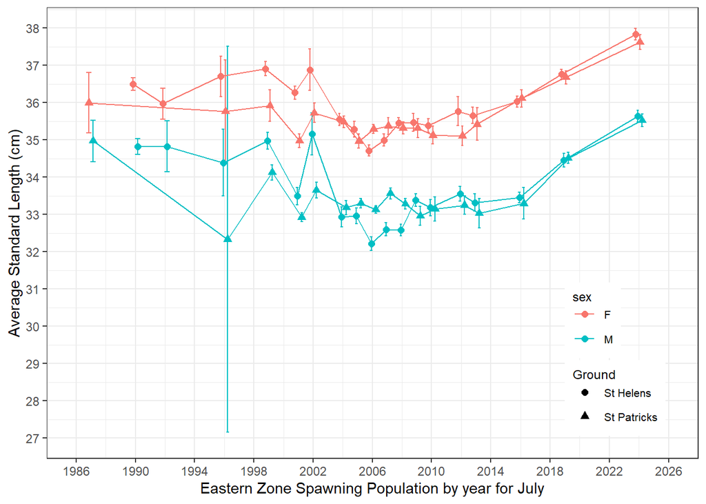

```r
#average SL by Area and sex

library(Rmisc)
library(ggplot2)

roughy_sum <- summarySE(Roughy_1, measurevar = "Length", groupvars = c("year","Ground","sex"))



pd <- position_dodge(0.6) # move position horizontally b/c of overlap

f2.1 <- ggplot(roughy_sum, aes(x = year,y = Length, shape = Ground, colour = sex)) +
  geom_errorbar(aes(ymin = Length - ci, ymax= Length + ci),
                width =.7, position = pd) +
  geom_point( position = pd, size = 2)+
  geom_line(position = pd) +
  xlab("Eastern Zone Spawning Population by year for July")+
  ylab("Average Standard Length (cm)")+
  scale_y_continuous(breaks = seq(27,38,1),limits = c(27,38))+
  scale_x_continuous(limits = c(1986,2026), breaks = seq(1986,2026,4))+
  theme_bw()+
  theme(legend.position = c(.95, .05),
        legend.justification = c(1,0),
        legend.text =element_text(size=8),
        legend.title = element_text(size = 9, margin = margin(t=.05)),
        legend.spacing.y =unit(.05,'cm'),
         plot.background = element_rect(linetype =  "solid") )
plot(f2.1)
```

```r
ggsave("Figures/LF_index.emf")
ggsave("Figures/LF_index.jpg")
```

| ### Length 2024 |
| --- |

```r
Roughy_2 <- Roughy_1 %>%
filter(year == 2024)
```

#### length data table

exploring the length data

```r
Roughy_2_length_GroundbySex <- summarySE(Roughy_2, measurevar = "Length",
                                      groupvars = c("Ground","sex"))
Roughy_2_length_GroundbySex
```

```
##        Ground sex   N   Length       sd         se        ci
## 1   St Helens   F 803 37.83064 2.197529 0.07754913 0.1522232
## 2   St Helens   M 605 35.63140 1.953433 0.07941833 0.1559696
## 3 St Patricks   F 490 37.62041 2.249924 0.10164122 0.1997074
## 4 St Patricks   M 478 35.52092 1.901831 0.08698773 0.1709265
```

```r
Roughy_2_length_Ground <- summarySE(Roughy_2, measurevar = "Length",
                                      groupvars = c("Ground"))
Roughy_2_length_Ground
```

```
##        Ground    N   Length       sd         se        ci
## 1   St Helens 1408 36.88565 2.361530 0.06293498 0.1234565
## 2 St Patricks  968 36.58368 2.333875 0.07501358 0.1472082
```

```r
Roughy_3 <-Roughy_2 %>%
  filter(SLadj_cm >= 42)

summarySE(Roughy_3, measurevar = "Length",
                                      groupvars = c("Ground","sex"))
```

```
##        Ground sex  N   Length       sd        se        ci
## 1   St Helens   F 39 42.64103 1.180704 0.1890640 0.3827400
## 2   St Helens   M  1 43.00000       NA        NA       NaN
## 3 St Patricks   F 20 43.20000 1.542384 0.3448875 0.7218578
## 4 St Patricks   M  1 42.00000       NA        NA       NaN
```

#### summaries

Table 2.4 (needs updating for future surveys to include shot without measures in “OR.R”)

[output not shown]

| Ground | Shot | Date | Shot Weight (kg) | F | M | Total Nos Fish | Ratio_F |
| --- | --- | --- | --- | --- | --- | --- | --- |
| St Helens | 18 | 9/07/2024 | 3468 | 52 | 8 | 60 | 0.8666667 |
| St Helens | 21 | 10/07/2024 | 28507 | 156 | 44 | 200 | 0.7800000 |
| St Helens | 23 | 11/07/2024 | 18032 | 89 | 78 | 167 | 0.5329341 |
| St Helens | 24 | 12/07/2024 | 5518 | 122 | 10 | 132 | 0.9242424 |
| St Helens | 25 | 12/07/2024 | 24040 | 99 | 50 | 149 | 0.6644295 |
| St Helens | 29 | 13/07/2024 | 2000 | 1 | 15 | 16 | 0.0625000 |
| St Helens | 30 | 13/07/2024 | 10112 | 27 | 107 | 134 | 0.2014925 |
| St Helens | 31 | 13/07/2024 | 24496 | 64 | 36 | 100 | 0.6400000 |
| St Helens | 32 | 14/07/2024 | 14050 | 59 | 41 | 100 | 0.5900000 |
| St Helens | 33 | 15/07/2024 | 22008 | 37 | 113 | 150 | 0.2466667 |
| St Helens | 36 | 16/07/2024 | 12007 | 30 | 70 | 100 | 0.3000000 |
| St Helens | 37 | 17/07/2024 | 13117 | 67 | 33 | 100 | 0.6700000 |
| St Patricks | 22 | 11/07/2024 | 8076 | 68 | 92 | 160 | 0.4250000 |
| St Patricks | 26 | 12/07/2024 | 20011 | 88 | 40 | 128 | 0.6875000 |
| St Patricks | 27 | 13/07/2024 | 6503 | 75 | 45 | 120 | 0.6250000 |
| St Patricks | 28 | 13/07/2024 | 10015 | 81 | 19 | 100 | 0.8100000 |
| St Patricks | 34 | 15/07/2024 | 8026 | 96 | 24 | 120 | 0.8000000 |
| St Patricks | 35 | 16/07/2024 | 27031 | 19 | 101 | 120 | 0.1583333 |
| St Patricks | 38 | 17/07/2024 | 11011 | 37 | 83 | 120 | 0.3083333 |
| St Patricks | 40 | 18/07/2024 | 8000 | 26 | 74 | 100 | 0.2600000 |

#### Data by shot: Length and derived weight

```r
Roughy_2_sum_L <- Roughy_2 %>%
  dplyr::group_by(Ground,Shot,sex) %>%
  dplyr::summarise(avgL = mean(Length)) %>%
  spread(sex,avgL) %>%
  mutate(F_Lgt =round(F,2), M_Lgt =round(M,2)) %>%
  select(-F,-M)
# check check this the input data "Wgt_derived" must have been generated down below - i have moved this code around for ease of reading for Paul Burch - but made a mistake in

# Roughy_2_sum_W <- Roughy_2 %>%
#   dplyr::group_by(Ground,Shot,sex) %>%
#   dplyr::summarise(avgW = mean(Wgt_derived)) %>%
#   spread(sex,avgW) %>%
#   mutate(F_Dw =round(F,2), M_DW =round(M,2)) %>%
#   ungroup() %>%
#   select(-F,-M,-Ground,-Shot)
#
# Roughy_2_sum_WFM <- Roughy_2 %>%
#   dplyr::group_by(Ground,Shot,sex) %>%
#   dplyr::summarise(avgWFM = mean(Wgt_derived_MF)) %>%
#   spread(sex,avgWFM) %>%
#   mutate(F_wFM =round(F,2), M_wFM =round(M,2)) %>%
#   ungroup() %>%
#   select(-F,-M,-Ground,-Shot)
#
#                    #avgwgt = mean(Wgt_derived),avgwgtMF = mean(Wgt_derived_MF))
# shotdata_LWW <- bind_cols(Roughy_2_sum_L,Roughy_2_sum_W,Roughy_2_sum_WFM)

  # t2.4 <- bind_rows(Roughy_2_sum, TSH, TSP,TSHSP) %>%   # put all together for totals
  # dplyr::rename("Shot Weight (kg)" = ShotWeight_kg, "Total Nos Fish" = Total)
```

#### Standard Length by sex and ground

```r
OR_LF <- Roughy_2 %>% # This is the ONE
  group_by(Ground, sex) %>%
  add_tally() %>%
  group_by(Ground, sex, Length) %>%
  dplyr::summarise(prop = n() / n[1])
```

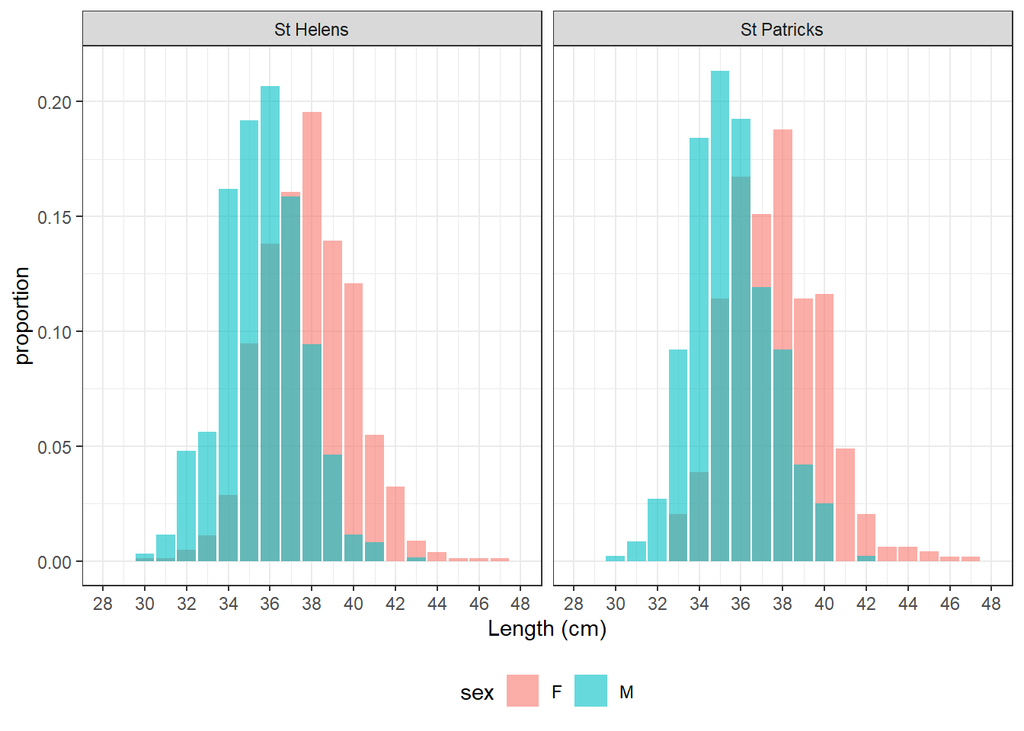

```r
f2.2 <- ggplot(OR_LF, aes(Length, prop, fill = sex)) +
  geom_col(position = "identity", alpha = 0.6) +
  scale_x_continuous(breaks = seq(28,48,2),limits = c(28,48))+
  facet_wrap(~Ground)+
   theme_bw()+
  ylab("proportion")+
  xlab("Length (cm)")+
  theme(legend.position = "bottom")
plot(f2.2)
```

```r
ggsave(filename = "Figures/LF2024.emf",device = emf)
ggsave(filename = "Figures/LF2024.jpg")
```

#### Cummunlative Frequency

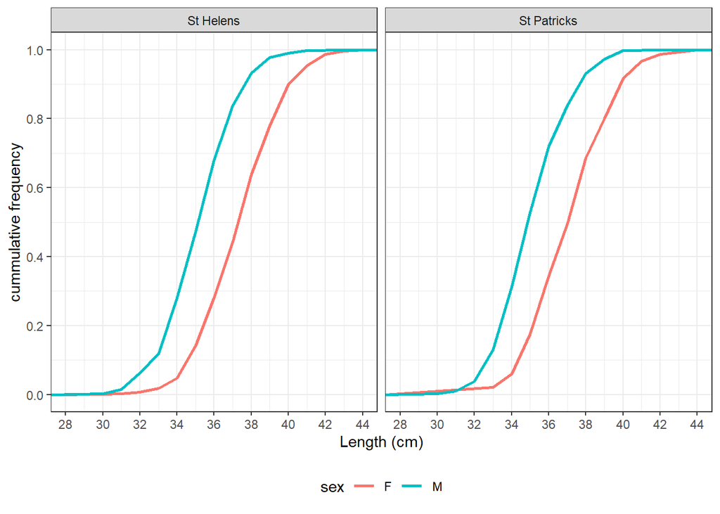

```r
#using stat_ecdf to calculate the cummulative frequency

f2.3 <- ggplot(Roughy_2,aes(x=Length, colour= sex)) +
   stat_ecdf(geom = "smooth")+
  scale_x_continuous(breaks = seq(28,44,2),limits = c(28,44))+
  scale_y_continuous(breaks = seq(0,1,0.2))+
  facet_wrap(~Ground)+
  ylab("cummulative frequency")+
  xlab("Length (cm)")+
  theme_bw()+
  theme(legend.position = "bottom")
plot(f2.3)
```

```r
ggsave(filename = "Figures/cumLF2024.emf")
```

#### Mode and Numbers of fish by Year, Ground, Sex

```r
#need to group by Ground and sex togehter so need to make a combined variable
Roughy_3 <- Roughy_1 %>%
  mutate(GbyS= paste(Ground,sex,sep = "_")) %>%  #new variable to combine Ground and sex
  group_by(GbyS) %>%
  mutate(sumsum = cumsum(Length))


#create function to find the mode
Mode <- function(x) {
    if (is.numeric(x)) {
        x_table <- table(x)
        return(as.numeric(names(x_table)[which.max(x_table)]))
        }
}

#calcuate the mode
Roughy_mode <- Roughy_3 %>%
  dplyr::group_by(year,GbyS) %>%
  dplyr::summarise(Mode = Mode(x = Length))%>%
  spread(GbyS, Mode)
#calcuate the  counts
Roughy_nos <- Roughy_3 %>%
  dplyr::group_by(year, GbyS) %>%
  dplyr::summarise(Numbers = n())%>%
  spread(GbyS, Numbers)
#bind the mode and counts
R_Mode_Count <-  cbind(Roughy_mode,Roughy_nos)%>%
  select(-6)#remove the year1 colomn
```

```r
t2.5<-  R_Mode_Count_order <- R_Mode_Count[,c(1,2,6,3,7,4,8,5,9)]  # order the columns

  write.csv(t2.5,"Figures/Lmode_index.csv")
  #note that this table is also saved as t2.4.doc in "OR Tables.Rmd"

knitr::kable(R_Mode_Count_order, col.names = c("", "Nos. Fish","Mode", "Nos. Fish","Mode", "Nos. Fish","Mode", "Nos. Fish","Mode"), format = "html", caption = " Figure 2.5. Number of Fish measured and mode of standard lengths (cm) for male and femailes measured at St Helens and St Particks from 1987 to 2019") %>%
  kableExtra::kable_styling("striped") %>%
  add_header_above(c(" ", "Female" = 2, "Male" = 2, "Female" = 2, "Male"=2)) %>%
    add_header_above(c(" ", "St Helens" = 4, "St Patricks" = 4)) %>%
    kableExtra::scroll_box(width = "100%")
```

[output not shown]

#### Average Length by Shot

Figure 2.4

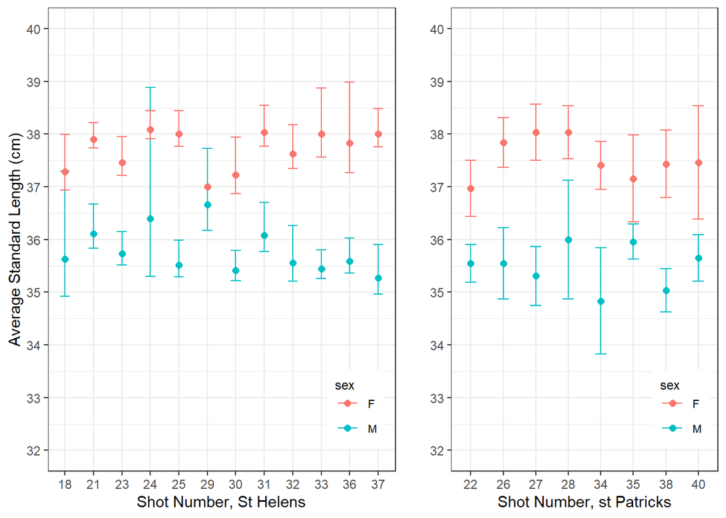

## ### Gonad Stages

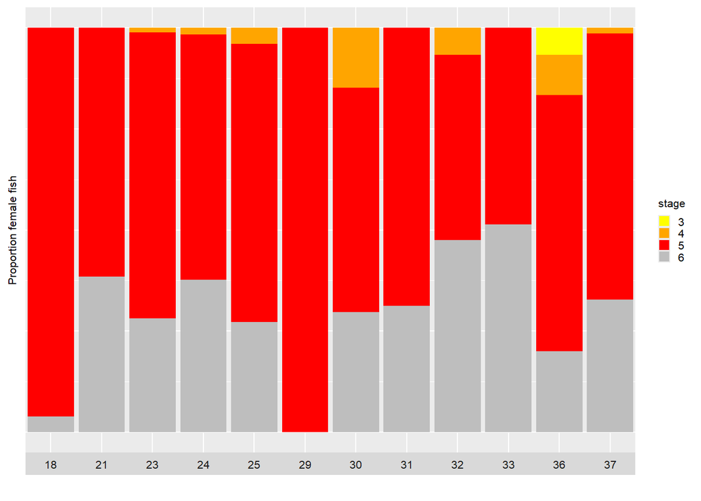

```r
#need to group the frame by sex
Roughy_4 <- Roughy_1%>%
  filter(year==2024) %>%
  mutate(stage = as.character(stage))%>%
 # mutate(Shot = as.character(Shot)) %>%
  mutate(Date= as.Date(Date,"%d/%m")) %>%
  #select(-Date) %>%
  group_by(sex)

OR2024_sumFH <- Roughy_2_lengthsum %>%
  filter(Ground == "St Helens", sex == "F")
OR2024_sumMH <- Roughy_2_lengthsum %>%
  filter(Ground == "St Helens", sex == "M")
OR2024_sumFP <- Roughy_2_lengthsum %>%
  filter(Ground == "St Patricks", sex == "F")
OR2024_sumMP <- Roughy_2_lengthsum %>%
  filter(Ground == "St Patricks", sex == "M")

# Fsh <- ggplot(Roughy_4 %>%
#   filter(Ground == "St Helens", sex == "F"),
#   aes(x = Date, fill = stage))+
#   geom_bar(position = "fill")+
#   scale_fill_manual(values = c("yellow","orange","red","grey"))+
#   theme(axis.text=element_text(size=9))+
#  facet_grid(.~Shot, scales = "free_x", switch ="x")+
#   theme(strip.text.x = element_text(size =8),
#         panel.spacing = unit(0,"mm"))+ # remove spacing between facets
#   theme(legend.position = "none")+
#   theme(axis.title.y = element_text(size = 11))+
#    theme(axis.title.x = element_text(size = 11),
#         axis.ticks = element_blank()) +
#   ylab("Proportion female fish")+
#   xlab("")

Fsh <- ggplot(Roughy_4 %>%
  filter(Ground == "St Helens", sex == "F"),
  aes(x = Date, fill = stage))+
  geom_bar(position = "fill")+
  scale_fill_manual(values = c("yellow","orange","red","grey"))+
  theme(axis.text= element_blank())+
 facet_grid(.~Shot, scales = "free_x", switch ="x")+
  theme(strip.text.x = element_text(size =8),
        panel.spacing = unit(0,"mm"))+ # remove spacing between facets
  #theme(legend.position = "none")+
  theme(legend.text=element_text(size=8))+
  theme(legend.title = element_text(size =8))+
  theme(legend.key.size = unit(.3,'cm'))+
  theme(axis.title.y = element_text(size = 8))+
   theme(axis.title.x = element_text(size = 8),
        axis.ticks = element_blank()) +
  ylab("Proportion female fish")+
  xlab("")

Msh <- ggplot(Roughy_4 %>%
  filter(sex == "M",Ground =="St Helens"),
  aes(x = Date, fill = stage))+
  geom_bar(position = "fill")+
  scale_fill_manual(values = c("yellow","orange","red","grey","black"))+
  theme(axis.text= element_blank())+
 facet_grid(.~Shot, scales = "free_x", switch ="x")+
    theme(strip.text.x = element_text(size =8),
        panel.spacing = unit(0,"mm"), # remove spacing between facets
        axis.title.x = element_text(size = 8),
        axis.ticks = element_blank())+
  theme(legend.text=element_text(size=8))+
  theme(legend.title = element_text(size =8))+
  theme(legend.key.size = unit(.3,'cm'))+
    theme(axis.title.y = element_text(size = 8))+
     theme(axis.title.x = element_text(size = 8),
        axis.ticks = element_blank()) +
  xlab("Shot Number, St Helens")+
  ylab("Proportion male fish")

Fsp <- ggplot(Roughy_4 %>%
  filter(sex == "F",Ground =="St Patricks"),
  aes(x = Date, fill = stage, ))+
  geom_bar(position = "fill")+
  labs(fill = "stage")+
  scale_fill_manual(values = c("yellow","orange","red","grey"))+
 theme(axis.text= element_blank())+
  facet_grid(.~Shot, scales = "free_x", switch ="x")+
  theme(strip.text.x = element_text(size =8),
        panel.spacing = unit(0,"mm"))+ # remove spacing between facets
   theme(axis.title.x = element_text(size = 8),
        axis.ticks = element_blank()) +
  theme(legend.text=element_text(size=8))+
  theme(legend.title = element_text(size =8))+
  theme(legend.key.size = unit(.3,'cm'))+
   ylab("")+
   xlab("")

Msp <- ggplot(Roughy_4 %>%
  filter(sex == "M",Ground =="St Patricks"),
  aes(x = Date, fill = stage))+
  geom_bar(position = "fill")+
    labs(fill = "stage")+
    scale_fill_manual(values = c("orange","red","grey","black"))+
    theme(axis.text= element_blank())+
  facet_grid(.~Shot, scales = "free_x", switch ="x")+
    theme(strip.text.x = element_text(size =8),
        panel.spacing = unit(0,"mm"), # remove spacing between facets
        axis.title.x = element_text(size = 8),
        axis.ticks = element_blank())+
  theme(legend.text=element_text(size=8))+
  theme(legend.title = element_text(size =8))+
  theme(legend.key.size = unit(.3,'cm'))+
  xlab("Shot Number, St Patricks")+
  ylab("")

plot(Fsh)
```

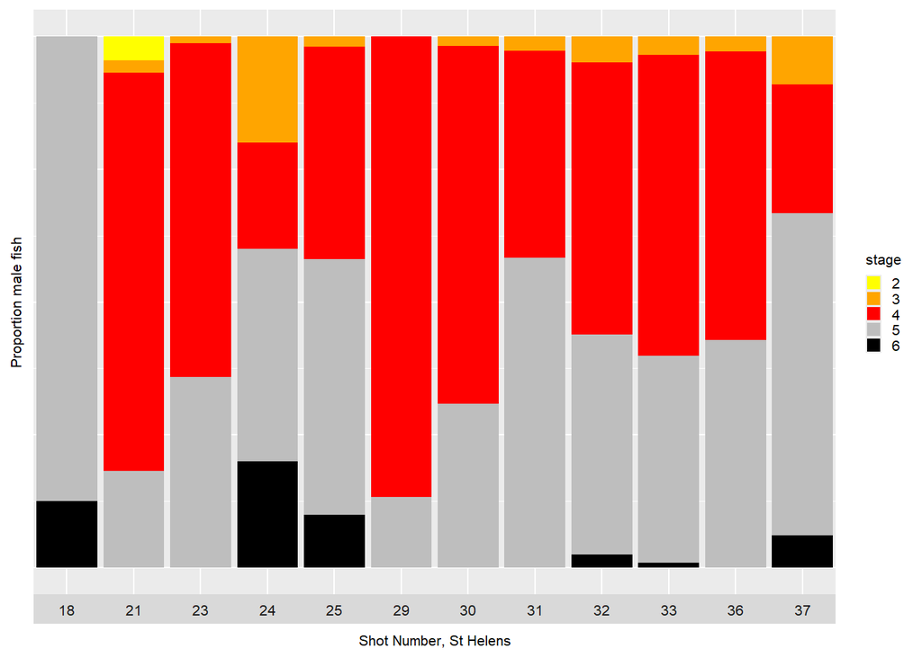

```r
plot(Msh)
```

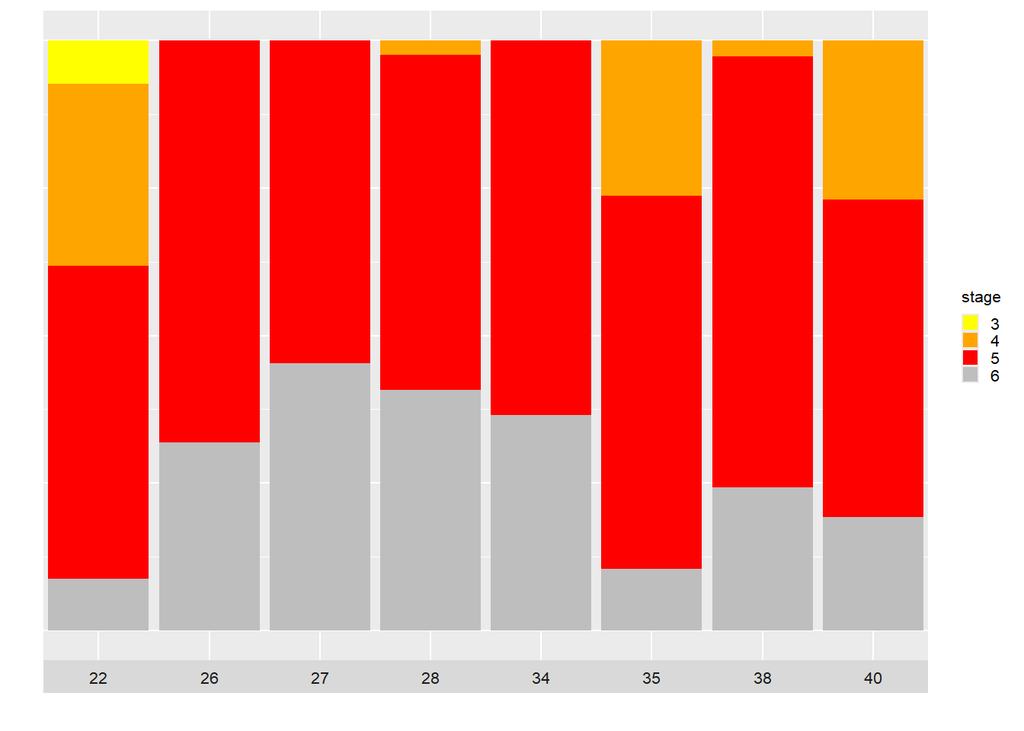

```r
plot(Fsp)
```

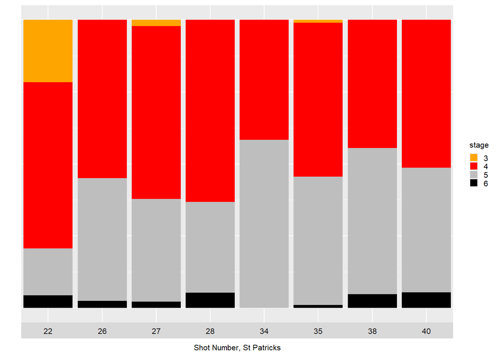

```r
plot(Msp)
```

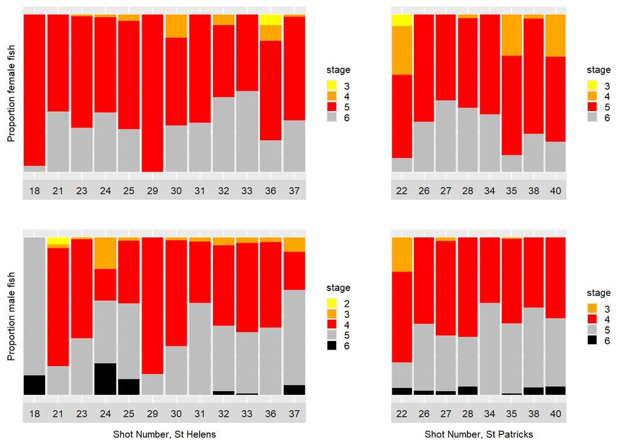

```r
grid.arrange(Fsh,Fsp,Msh, Msp, ncol=2, nrow=2, widths= c(14,10), heights= c(8,8)) #arrange plot into a grid (this does not save it only plots to view)
```

```r
f2.5 <- arrangeGrob(Fsh,Fsp,Msh, Msp, ncol=2, nrow=2, widths= c(11,8.5), heights= c(5,5)) # creates plot as an object


ggsave("Figures/GonadStage.emf",f2.5) # saves the plot to file :)
ggsave("Figures/GonadStage.jpeg",f2.5) # saves the plot to file :)
```

#### gonad stage summary

exploring gonad data

```r
Roughy_4 %>%
  filter(Ground =="St Patricks") %>%
  add_tally() %>%
  dplyr::group_by(sex,stage) %>%
 dplyr::summarise(prop = n()/ n[1])
```

[output not shown]

```
## # A tibble: 8 × 3
## # Groups:   sex [2]
##   sex   stage   prop
##   <chr> <chr>  <dbl>
## 1 F     3     0.0102
## 2 F     4     0.0735
## 3 F     5     0.606
## 4 F     6     0.310
## 5 M     3     0.0460
## 6 M     4     0.529
## 7 M     5     0.391
## 8 M     6     0.0335
```

```r
Roughy_4 %>%
  add_tally() %>%
  dplyr::group_by(sex,stage) %>%
 dplyr::summarise(n())
```

[output not shown]

```
## # A tibble: 9 × 3
## # Groups:   sex [2]
##   sex   stage `n()`
##   <chr> <chr> <int>
## 1 F     3         7
## 2 F     4        55
## 3 F     5       816
## 4 F     6       415
## 5 M     2         2
## 6 M     3        41
## 7 M     4       587
## 8 M     5       425
## 9 M     6        28
```

```r
  # group_by(Ground, sex) %>%
  # add_tally() %>%
  # group_by(Ground, sex, Length) %>%
  # dplyr::summarise(prop = n() / n[1])
```

| ### sex ratios |
| --- |